# Inferência Estatística e Regressão Linear

👩🏽‍💻 Eduarda Michaelle

(data: 10/12/2022)

# Download de pacotes e bibliotecas

```r
install.packages("devtools")
devtools::install_github("fnaufel/fnaufelRmd")
if (!require('devtools'))
  install.packages('devtools')
if (!require('fnaufelRmd'))
  devtools::install_github("fnaufel/fnaufelRmd")
pacotes <- c(
  'conflicted',
  'kableExtra',
  'knitr',
  'latex2exp',
  'sessioninfo',
  'summarytools',
  'tidyverse'
)

instalar_se_preciso <- function(x) {

  if (!require(x, character.only = TRUE))
    install.packages(x)

}

invisible(sapply(pacotes, instalar_se_preciso))
```

```
## system might not have X11 capabilities; in case of errors when using dfSummary(), set st_options(use.x11 = FALSE)
```

```r
install.packages("binom")
library(scales)
```

# Moeda

1. Usando apenas a linha da tabela que corresponde a você, teste a hipótese de que a moeda é justa — i.e., em um lançamento, a moeda produz cara com probabilidade $p = 0{,}5$. Use $\alpha = 0{,}05$.

**Resposta:**

- A linha que corresponde a mim é a da matrícula **218060060**, com **70** caras.

## Condições

- Vamos verificar as condições para ver se o teste de hipótese também se baseia no TCL:
1. **Idependência:** os lançamentos das moedas são independentes entre si? Sim, pois um resultado não depende do outro.
2. **Amostra aleatória e representativa:** a amostra são os 200 lançamentos. A população consiste em todas as moedas lançadas em um dia em questão. Vamos supor que os números de lançamentos de cada dia são compatíveis com os outros.
3. **Tamanho da amostra:** temos mais do que 30 elementos e a amostra é menor do que 10% da população.
4. **Quantidades de sucessos e fracassos potenciais:** considerando cara como sucesso e coroa para fracassos, temos 70 sucessos e 130 fracassos, mais do que os 10 exigidos.
- As condições foram verificadas 👍

## Valores

```r
n <- 200
p_chapeu <- 70/200
p0 <- 0.5
ep <- sqrt(p0 * (1 - p0) / n)
```

- Tamanho da amostra: $n =200$
- Proporção amostral: $\hat p = 0,35$
- Hipótese de nulidade: $H_0 : p = 0,5$
- Hipótese alternativa: $H_A : p < 0,5$
- Nível de significância: $\alpha = 0,05$

## Testando a hipótese

- Começamos supondo que $H_0$ é verdadeira.
- Pelo TCL e supondo $H_0$, construímos a distribuição amostral, com média $\mu = p = 0,5$

$$\sigma_{\hat p}
= \sqrt{\frac{p(1-p)}{n}}
= 0.03535534$$

- Agora, usando essa distribuição amostral, vamos calcular a aprobabilidade de obter uma amostra como a que obtivemos ou mais externa:

```r
valor_p <- pnorm(p_chapeu, mean = p0, sd = ep, lower.tail = FALSE)
valor_p
```

```
## [1] 0.999989
```

## Teste em R

```r
prop.test(
  x = p_chapeu * n,          # número de sucessos
  n = n,                     # tamanho da amostra
  p = p0,                    # valor de p na hipótese de nulidade
  alternative = 'less',      # hipótese alternativa é p < p0
  conf.level = .95,          # 1 - α (o default já é .95)
  correct = FALSE            # sem correção de continuidade
)
```

```
##
##  1-sample proportions test without continuity correction
##
## data:  p_chapeu * n out of n, null probability p0
## X-squared = 18, df = 1, p-value = 1.105e-05
## alternative hypothesis: true p is less than 0.5
## 95 percent confidence interval:
##  0.0000000 0.4071427
## sample estimates:
##    p
## 0.35
```

## Intervalo de confiança

- Em uma distribuição normal com média $\mu$ e desvio padrão $\sigma$, sabemos que $95\%$ da probabilidade está entre $\mu - 1{,}96\sigma$ e $\mu + 1{,}96\sigma$.
- Primeiro, vamos calcular o erro padrão:

$$EP = \sqrt{\frac{\hat p(1-\hat p)}{n}}$$

```r
ep2 <- sqrt(p_chapeu * (1 - p_chapeu) / n)
ep2
```

```
## [1] 0.03372684
```

- Para 95%, precisamos usar 1,96 como número de desvio padrão.
- Agora, vamos calcular a margem de erro:

```r
margem <- 1.96 * ep2
margem
```

```
## [1] 0.06610461
```

- Por último, calculamos os extremos do intervalo de confiança:

```r
p_chapeu + c(-1,1) * margem
```

```
## [1] 0.2838954 0.4161046
```

## Intervalo em R

- Criando a função $bt$ que terá como retorno uma lista:

```r
bt <- binom.test(70, 200)
bt
```

```
##
##  Exact binomial test
##
## data:  70 and 200
## number of successes = 70, number of trials = 200, p-value = 2.653e-05
## alternative hypothesis: true probability of success is not equal to 0.5
## 95 percent confidence interval:
##  0.2840707 0.4204506
## sample estimates:
## probability of success
##                   0.35
```

- Gerando o intervalo de confiança:

```r
bt$conf.int
```

```
## [1] 0.2840707 0.4204506
## attr(,"conf.level")
## [1] 0.95
```

# Lei de Moore pra GPUs

- Usaremos o *dataset* abaixo:

```r
gpus <- read_csv2(
  paste0('https://raw.githubusercontent.com/fnaufel/', 'CursoProbEst/master/Aulas/23-regressao1/data/gpus.csv')
  ) %>% select(
    processador = Processor,
    transistores = 'Transistor count',
    ano = 'Date of introduction',
    fabricante = Manufacturer
  )
```

```
## ℹ Using "','" as decimal and "'.'" as grouping mark. Use `read_delim()` for more control.
```

```r
gpus
```

```
## # A tibble: 35 × 4
##    processador transistores   ano fabricante
##    <chr>              <dbl> <dbl> <chr>
##  1 NV3              3500000  1997 NVIDIA
##  2 Rage 128         8000000  1999 AMD
##  3 NV5             15000000  1999 Nvidia
##  4 NV10            23000000  1999 Nvidia
##  5 NV11            20000000  2000 Nvidia
##  6 NV15            25000000  2000 Nvidia
##  7 R100            30000000  2000 AMD
##  8 NV20            57000000  2001 Nvidia
##  9 R200            60000000  2001 AMD
## 10 NV25            63000000  2002 Nvidia
## # … with 25 more rows
```

- Vamos utilizar regressão linear para confirmar a lei de Moore para estes dados:

## Examinando o *scatterplot*

- Começamos analisando o gráfico da quantidade de transistores por ano:

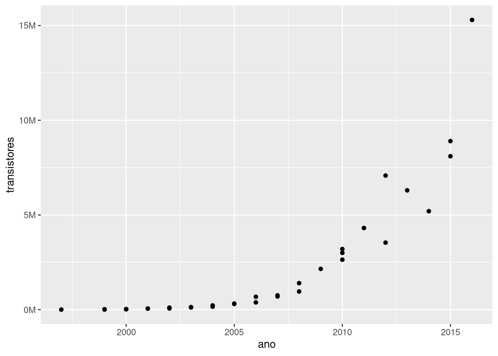

```r
gpus %>%
  ggplot(aes(ano, transistores)) +
    geom_point() +
    scale_y_continuous(
      labels = label_number(scale = 1e-9, decimal.mark = ',', suffix = 'M')
    )
```

- Podemos ver que a relação não é linear, pois a [lei de Moore](https://pt.wikipedia.org/wiki/Lei_de_Moore) estima que, a cada dois anos, o número de transistores em um circuito integrado dobra, i.e., a relação é exponencial.
- Logo, não poderemos fazer regressão linear com uma variável que varia exponencialmente em relação à outra.
- A solução para esse problema é usar o logaritmo do número de transistores para criar um novo gráfico:

```r
gpus <- gpus %>% mutate(ltransistores = log10(transistores))
```

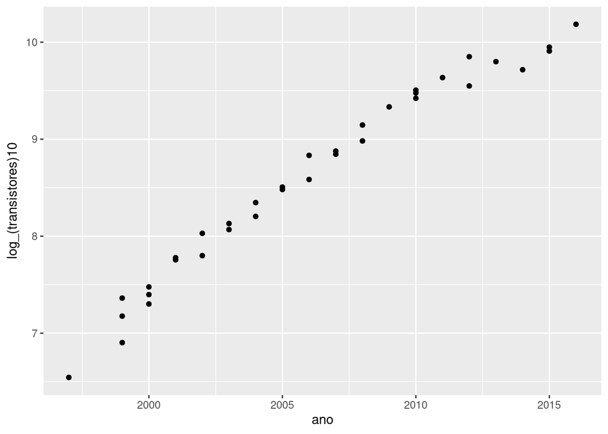

```r
grafico <- gpus %>%
  ggplot(aes(ano, ltransistores)) +
  geom_point() +
  labs(
    y = TeX('log_{10}(transistores)')
    )

grafico
```

- Agora temos uma núvem de pontos que parece mostrar uma correlação linear.

## Construindo o modelo

```r
modelo <- lm(ltransistores ~ ano, data = gpus)
```

```r
summary(modelo)
```

```
##
## Call:
## lm(formula = ltransistores ~ ano, data = gpus)
##
## Residuals:
##      Min       1Q   Median       3Q      Max
## -0.40084 -0.10683  0.05779  0.12273  0.25285
##
## Coefficients:
##               Estimate Std. Error t value Pr(>|t|)
## (Intercept) -3.572e+02  1.178e+01  -30.32   <2e-16 ***
## ano          1.823e-01  5.873e-03   31.05   <2e-16 ***
## ---
## Signif. codes:  0 '***' 0.001 '**' 0.01 '*' 0.05 '.' 0.1 ' ' 1
##
## Residual standard error: 0.1843 on 33 degrees of freedom
## Multiple R-squared:  0.9669, Adjusted R-squared:  0.9659
## F-statistic:   964 on 1 and 33 DF,  p-value: < 2.2e-16
```

- A equação é:

$$\widehat{\text{log(transistores)}} = -357,1896 + 0,1823379 \cdot
\text{ano}$$

- A equação diz que, a cada $2$ anos, o logaritmo do número de transistores (na base $10$) aumenta de $0,3646759$.
- Chamando de $t(n)$ o número de transistores no ano $n$, a equação diz que:

$$\begin{align*}
\log t(n + 2) = \log t(n) + 0.3646759
& \implies
t(n + 2) = t(n) \cdot 10^{0.3646759}
& \text{(elevando }10\text{ a cada lado)} \\
& \implies
t(n + 2) = 2.316 \cdot t(n)
\end{align*}$$

- Analisamos que no ano $n + 2$ a quantidade de transistores é de $2,316$ vezes a quantidade do ano $n$.
- Isso mostra que a Lei de Moore não se aplica as GPUs com tanta pontualidade 👎